# Effects of Inhibition on Trial Signals in 'numberStarred' Game

## N of 1 Trial Study

### By Marko Seslija

## Abstract

- In this notebook we explore the effects of inhibition on the movement sensors data.
- This is an N of 1 trial. We exclusively concentrate on a specific (any) individual.

## 2nd Order Statistics of Trajectories

- Load the data by running *parserGP.py*.
- Fit Gaussian processes to the triggering angle (one that cuases app to register event) and the remaining angle.
- We use standar RBF kernel.

```python
%run -i 'parserGP.py'
```

[output not shown]

[output not shown]

[output not shown]

[output not shown]

```
ID: 35  Game: numbersStarred   Session: 4   Window: 0   Time: 2019-02-12 09:31:17.914885
ID: 35  Game: numbersStarred   Session: 4   Window: 1   Time: 2019-02-12 09:31:20.151089
ID: 35  Game: numbersStarred   Session: 4   Window: 2   Time: 2019-02-12 09:31:21.467788
ID: 35  Game: numbersStarred   Session: 4   Window: 3   Time: 2019-02-12 09:31:24.868065
ID: 35  Game: numbersStarred   Session: 4   Window: 4   Time: 2019-02-12 09:31:27.051416
ID: 35  Game: numbersStarred   Session: 4   Window: 5   Time: 2019-02-12 09:31:28.818162
ID: 35  Game: numbersStarred   Session: 4   Window: 6   Time: 2019-02-12 09:31:30.401603
ID: 35  Game: numbersStarred   Session: 4   Window: 7   Time: 2019-02-12 09:31:32.018409
ID: 35  Game: numbersStarred   Session: 4   Window: 8   Time: 2019-02-12 09:31:34.603134
ID: 35  Game: numbersStarred   Session: 4   Window: 9   Time: 2019-02-12 09:31:37.035278
ID: 35  Game: numbersStarred   Session: 4   Window: 10   Time: 2019-02-12 09:31:39.953552
ID: 35  Game: numbersStarred   Session: 4   Window: 11   Time: 2019-02-12 09:31:41.670444
ID: 35  Game: numbersStarred   Session: 4   Window: 12   Time: 2019-02-12 09:31:43.270058
ID: 35  Game: numbersStarred   Session: 4   Window: 13   Time: 2019-02-12 09:31:45.702396
ID: 35  Game: numbersStarred   Session: 4   Window: 14   Time: 2019-02-12 09:31:49.637416
ID: 35  Game: numbersStarred   Session: 4   Window: 15   Time: 2019-02-12 09:31:51.721304
ID: 35  Game: numbersStarred   Session: 4   Window: 16   Time: 2019-02-12 09:31:54.820826
ID: 35  Game: numbersStarred   Session: 4   Window: 17   Time: 2019-02-12 09:31:57.136693
ID: 35  Game: numbersStarred   Session: 4   Window: 18   Time: 2019-02-12 09:32:00.269855
ID: 35  Game: numbersStarred   Session: 4   Window: 19   Time: 2019-02-12 09:32:03.271319
ID: 35  Game: numbersStarred   Session: 4   Window: 20   Time: 2019-02-12 09:32:05.353427
ID: 35  Game: numbersStarred   Session: 4   Window: 21   Time: 2019-02-12 09:32:09.703775
ID: 35  Game: numbersStarred   Session: 4   Window: 22   Time: 2019-02-12 09:32:12.320514
ID: 35  Game: numbersStarred   Session: 4   Window: 23   Time: 2019-02-12 09:32:16.454029
ID: 35  Game: numbersStarred   Session: 4   Window: 24   Time: 2019-02-12 09:32:18.570810
ID: 35  Game: numbersStarred   Session: 4   Window: 25   Time: 2019-02-12 09:32:19.970864
ID: 35  Game: numbersStarred   Session: 4   Window: 26   Time: 2019-02-12 09:32:22.554376
ID: 35  Game: numbersStarred   Session: 4   Window: 27   Time: 2019-02-12 09:32:25.671227
ID: 35  Game: numbersStarred   Session: 4   Window: 28   Time: 2019-02-12 09:32:28.371349
ID: 35  Game: numbersStarred   Session: 4   Window: 29   Time: 2019-02-12 09:32:30.971479
ID: 35  Game: numbersStarred   Session: 4   Window: 30   Time: 2019-02-12 09:32:32.838278
ID: 35  Game: numbersStarred   Session: 4   Window: 31   Time: 2019-02-12 09:32:34.573085
Average time of compleation of numbersStarredin consecutive sessions
[2.84973593 2.86168225 2.31845416 2.10353207 1.79486212]
Number of incorrect answers
[5, 3, 2, 2, 0]
```

```
Correlation between event and reaction times: nan
Correlation between event and reaction times without nans: 0.9947582766727342
Correlation between event times without nans and L1: 0.15964043067053865
Total incorrect (%):           6.779661016949152
Incorrect with Star (%):       41.66666666666667
Fallen for Star (%):           16.666666666666664
Incorrect without Star (%):    58.333333333333336
Incorrect with flip (%):       0.0
Incorrect without flip (%):    100.0
Total incorrect via flip (%):  100.0
Total incorr. with lure (%):   66.66666666666666
Incorr. 2nd and 3rd attempt:   8.333333333333332
```

- Code for fitting Gaussian processes to response trajectories.

```python
from sklearn.kernel_ridge import KernelRidge
from sklearn.model_selection import GridSearchCV
from sklearn.gaussian_process import GaussianProcessRegressor
from sklearn.gaussian_process.kernels import WhiteKernel, ExpSineSquared, RBF

def fitGPs():
    # correct signals with Star
    data_Star = signals_trigger[numpy.where((corrIncorr_label==1) & (array_st_all==1))]
    # correct signals without Star
    data_noStar = signals_trigger[numpy.where((corrIncorr_label==1) & (array_st_all==0))]


    time_Star = numpy.zeros(shape=(int(len(data_Star)*101)), dtype=float)
    y_Star = numpy.zeros(shape=(int(len(data_Star)*101)), dtype=float)
    t_int_Star = numpy.array([i for i in range(0,101)])
    for j in range(int(len(data_Star))):
        for i in range(101):
            time_Star[j*101+i] = t_int_Star[i] + 0.01*numpy.random.uniform()
            y_Star[j*101+i] = data_Star[j,i]

    time_noStar = numpy.zeros(shape=(int(len(data_noStar)*101)), dtype=float)
    y_noStar = numpy.zeros(shape=(int(len(data_noStar)*101)), dtype=float)
    t_int_noStar = numpy.array([i for i in range(0,101)])
    for j in range(int(len(data_noStar))):
        for i in range(101):
            time_noStar[j*101+i] = t_int_noStar[i] + 0.01*numpy.random.uniform()
            y_noStar[j*101+i] = data_noStar[j,i]

    rng = numpy.random.RandomState(0)

    # Star
    y = y_Star[~numpy.isnan(y_Star.reshape(-1,1)).any(axis=1)]
    t = time_Star[numpy.where(~numpy.isnan(y_Star))]
    data_Star = numpy.vstack((t,y)).T

    mask_Star = numpy.random.choice([False, True], len(data_Star), p=[0.75, 0.25])
    data_sampled_Star = data_Star[mask_Star]
    t_data_Star = data_sampled_Star[:,0]
    y_data_Star = data_sampled_Star[:,1]

    # noStar
    y = y_noStar[~numpy.isnan(y_noStar.reshape(-1,1)).any(axis=1)]
    t = time_noStar[numpy.where(~numpy.isnan(y_noStar))]
    data_noStar = numpy.vstack((t,y)).T

    mask_noStar = numpy.random.choice([False, True], len(data_noStar), p=[0.75, 0.25])
    data_sampled_noStar = data_noStar[mask_noStar]
    t_data_noStar = data_sampled_noStar[:,0]
    y_data_noStar = data_sampled_noStar[:,1]

    gp_kernel = 1.0 * RBF(length_scale=1.0, length_scale_bounds=(1e-1, 1e2)) \
                + WhiteKernel(1e-2)
    gpr_Star = GaussianProcessRegressor(kernel=gp_kernel)
    gpr_Star.fit(t_data_Star.reshape(-1,1), y_data_Star.reshape(-1,1))

    gpr_noStar = GaussianProcessRegressor(kernel=gp_kernel)
    gpr_noStar.fit(t_data_noStar.reshape(-1,1), y_data_noStar.reshape(-1,1))

    # make predictions and plot
    t_plot = t_int_Star.reshape(-1,1)
    y_gpr_Star, y_std_Star = gpr_Star.predict(t_plot, return_std=True)
    y_gpr_noStar, y_std_noStar = gpr_noStar.predict(t_plot, return_std=True)

    plt.figure(figsize=(10, 5))
    plt.scatter(t_data_Star, y_data_Star, c='orangered', s=20, marker=(5, 2), label='data with Star')
    plt.scatter(t_data_noStar, y_data_noStar, c='dodgerblue', s=20, label='data without Star')
    plt.plot(t_plot, y_gpr_Star, color='orangered', lw=3,
             label='mean GP with Star')
    plt.fill_between(t_plot.ravel(), (y_gpr_Star - 2*y_std_Star.reshape(-1,1)).ravel(),
                     (y_gpr_Star + 2*y_std_Star.reshape(-1,1)).ravel(), color='darkorange',
                     alpha=0.3)
    plt.plot(t_plot, y_gpr_noStar, color='royalblue', lw=3,
             label='mean GP without Star')
    plt.fill_between(t_plot.ravel(), (y_gpr_noStar - 2*y_std_noStar.reshape(-1,1)).ravel(),
                     (y_gpr_noStar + 2*y_std_noStar.reshape(-1,1)).ravel(), color='lightskyblue',
                     alpha=0.3)
    plt.xlabel('time samples')
    plt.ylabel('triggering angle')
    plt.legend()
    plt.show()
```

## Fitting GPs

- Let us take a look how on average angle responses look when **Star** cursor is present and when it is absent.
- We discard first 150 ms of the response and map all responses $r_i(t)$, $t\in[150\,ms,T_i]$, to $\mathrm{sign}(r_i(T_i))\, r_i(t)$, where $T_i$ is the Event Time of $i$-th response $r_i$.
- Scale all $[150\,ms,T_i]$ to $[0,100]$.

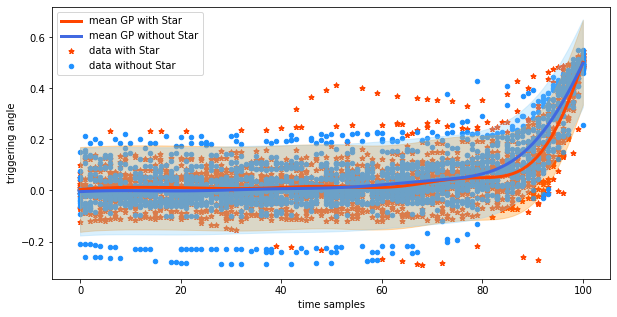

```python
# Fit Gaussian processes with RBFs
fitGPs()
```

- As we can see, it is very difficult to notice any difference on the basis of GPs.
- This motivates us to construct performance measures, which aim to capture a subtle difference in trajectories.

## Output Measures

- For the response Euler angles $\alpha(t),\beta(t), \gamma(t)$, we focus on a triggering angle $\alpha$ (the one that causes an event to be recorded) and a following angle $\beta$.
- We disregard the third angle.
- $L_1$-norms:

$$\| \alpha(t)\| = \frac{1}{T} \int_0^T \left| \frac{1}{2} - \mathrm{sign\,}(\alpha(T))\, \alpha(t)\right| dt$$$$\| \beta(t)\| = \frac{1}{T} \int_0^T \left| \beta(T) \right| dt$$

- Maximal Deviation in the opposite direction
- Number of turns a signal makes (characterized by change of the gradient)
- Sample Entropy

## Computing Output Measures

Load the Python script which will extract the outcome measures for us.